# Project: Data Wrangling

## Dataset Presentation:

The data presented is from **WeRateDogs** twitter account. It is about rating dogs based on their pictures. The dataset provided is composed of three datasets: the `twitter archive`, the `image predictions` and the `additional data` provided from the twitter API. The `twitter archive` contains data about tweets posted by the WeRateDogs twitter account. The data frame involves **metadata** about the tweet (id, timestamp, url & source), the **text** of the tweet, the **reply and retweet status**, the ratings and the dog stages (*puppo*, *doggo*, *pupper* and *floofer*) given by WeRateDogs. The `image predictions` table contains predictions made by a neural network based on the pictures of the dogs provided in the tweets. The `additional data` provided by the API contains the favorite count and retweet count for each tweet.

### Exemple of a tweet entry

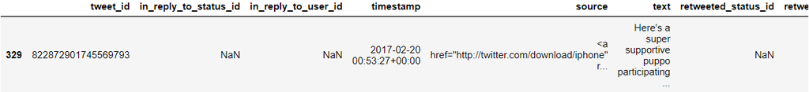

## Insights:

After analyzing the dataset, we've came across these insights:

1. The dog stage with the **highest favorite count** is **pupper**: Each dog is categorized into one of the four dog stages. By calculating the highest accumulative favorite count for each dog stage, we've found:
   1. pupper: 1,461,141 favorites
   2. doggo: 1,219,452 favorites
   3. puppo: 474,806 favorites
   4. floofer: 92,442 favorites
2. The **highest recorded favorite count** for a dog is **132810**: The dog's name is unspecified. The rating received is *13/10*. The retweet count for the same dog is *48265*.
3. The dog stage with the **most retweets** is **doggo**: The order goes as follows:
   1. doggo: 529,404 retweets
   2. pupper: 518,324 retweets
   3. puppo: 147,923 retweets
   4. floofer: 34,781 retweets
4. **26%** of the algorithm's **#1** predictions are **not dog breeds**: Every algorithm has its limitations. In this case, *26%* of the algorithm's predictions were not dog breeds (*paper towel*, *orange*, *bagel* etc..)

## Visualization:

We've visualized the **average favorite count** for **each of the dog stages** and we got the following figure:

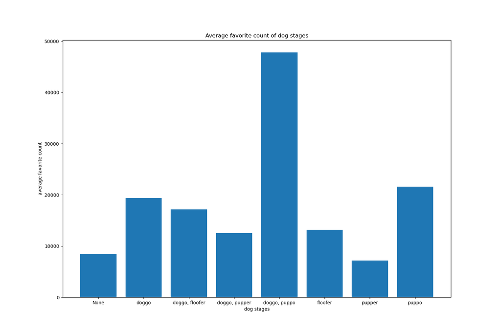